# Tipologia i cicle de vida de les dades: Pràctica 2

Anem ha estudiar la relació que hi ha entre el número acumulat de supervivents i el número acumulat segons sexe, classe i edat. Volem estudiar com es relacionen la variable acumulada cSurvived i la resta de variables acumulades a l’hora de ser bons predictors de la primara.

```r
model = lm(cSurvived ~ cSex, data = Titanic)
summary(model)
```

```
##
## Call:
## lm(formula = cSurvived ~ cSex, data = Titanic)
##
## Residuals:
##     Min      1Q  Median      3Q     Max
## -61.784 -24.599   0.921  17.210 100.222
##
## Coefficients:
##             Estimate Std. Error t value Pr(>|t|)
## (Intercept) 8.807150   1.867835   4.715 2.57e-06 ***
## cSex        1.208093   0.005278 228.887  < 2e-16 ***
## ---
## Signif. codes:  0 '***' 0.001 '**' 0.01 '*' 0.05 '.' 0.1 ' ' 1
##
## Residual standard error: 34.13 on 2099 degrees of freedom
## Multiple R-squared:  0.9615, Adjusted R-squared:  0.9615
## F-statistic: 5.239e+04 on 1 and 2099 DF,  p-value: < 2.2e-16
```

```r
model = lm(cSurvived ~ cAdult, data = Titanic)
summary(model)
```

```
##
## Call:
## lm(formula = cSurvived ~ cAdult, data = Titanic)
##
## Residuals:
##      Min       1Q   Median       3Q      Max
## -104.920  -22.320    6.619   28.883   42.987
##
## Coefficients:
##              Estimate Std. Error t value Pr(>|t|)
## (Intercept) 1.046e+02  1.452e+00   72.06   <2e-16 ***
## cAdult      1.457e-01  6.189e-04  235.46   <2e-16 ***
## ---
## Signif. codes:  0 '***' 0.001 '**' 0.01 '*' 0.05 '.' 0.1 ' ' 1
##
## Residual standard error: 33.22 on 2099 degrees of freedom
## Multiple R-squared:  0.9635, Adjusted R-squared:  0.9635
## F-statistic: 5.544e+04 on 1 and 2099 DF,  p-value: < 2.2e-16
```

```r
model = lm(cSurvived ~ cClass0, data = Titanic)
summary(model)
```

```
##
## Call:
## lm(formula = cSurvived ~ cClass0, data = Titanic)
##
## Residuals:
##     Min      1Q  Median      3Q     Max
## -321.11  -65.11   18.98   97.89  164.22
##
## Coefficients:
##              Estimate Std. Error t value Pr(>|t|)
## (Intercept) 321.10735    3.09754  103.67   <2e-16 ***
## cClass0       0.52476    0.01091   48.12   <2e-16 ***
## ---
## Signif. codes:  0 '***' 0.001 '**' 0.01 '*' 0.05 '.' 0.1 ' ' 1
##
## Residual standard error: 119.9 on 2099 degrees of freedom
## Multiple R-squared:  0.5245, Adjusted R-squared:  0.5242
## F-statistic:  2315 on 1 and 2099 DF,  p-value: < 2.2e-16
```

```r
model = lm(cSurvived ~ cClass1, data = Titanic)
summary(model)
```

```
##
## Call:
## lm(formula = cSurvived ~ cClass1, data = Titanic)
##
## Residuals:
##     Min      1Q  Median      3Q     Max
## -246.12 -101.28   10.88  105.88  222.64
##
## Coefficients:
##               Estimate Std. Error t value Pr(>|t|)
## (Intercept) -114.20975   12.05544  -9.474   <2e-16 ***
## cClass1        1.74479    0.03977  43.876   <2e-16 ***
## ---
## Signif. codes:  0 '***' 0.001 '**' 0.01 '*' 0.05 '.' 0.1 ' ' 1
##
## Residual standard error: 125.6 on 2099 degrees of freedom
## Multiple R-squared:  0.4784, Adjusted R-squared:  0.4781
## F-statistic:  1925 on 1 and 2099 DF,  p-value: < 2.2e-16
```

```r
model = lm(cSurvived ~ cClass2, data = Titanic)
summary(model)
```

```
##
## Call:
## lm(formula = cSurvived ~ cClass2, data = Titanic)
##
## Residuals:
##      Min       1Q   Median       3Q      Max
## -170.325  -75.325    3.448   72.428  172.374
##
## Coefficients:
##             Estimate Std. Error t value Pr(>|t|)
## (Intercept) 96.23290    4.52881   21.25   <2e-16 ***
## cClass2      1.39101    0.01859   74.81   <2e-16 ***
## ---
## Signif. codes:  0 '***' 0.001 '**' 0.01 '*' 0.05 '.' 0.1 ' ' 1
##
## Residual standard error: 90.83 on 2099 degrees of freedom
## Multiple R-squared:  0.7272, Adjusted R-squared:  0.7271
## F-statistic:  5597 on 1 and 2099 DF,  p-value: < 2.2e-16
```

```r
model = lm(cSurvived ~ cClass3, data = Titanic)
summary(model)
```

```
##
## Call:
## lm(formula = cSurvived ~ cClass3, data = Titanic)
##
## Residuals:
##      Min       1Q   Median       3Q      Max
## -200.463  -47.970    5.855   52.855  113.849
##
## Coefficients:
##              Estimate Std. Error t value Pr(>|t|)
## (Intercept) 2.005e+02  2.356e+00    85.1   <2e-16 ***
## cClass3     5.209e-01  4.782e-03   108.9   <2e-16 ***
## ---
## Signif. codes:  0 '***' 0.001 '**' 0.01 '*' 0.05 '.' 0.1 ' ' 1
##
## Residual standard error: 67.43 on 2099 degrees of freedom
## Multiple R-squared:  0.8497, Adjusted R-squared:  0.8496
## F-statistic: 1.187e+04 on 1 and 2099 DF,  p-value: < 2.2e-16
```

Observem que sexe i l’edat són molt bons predictors amb coeficients de determinació 0.9615 i 0.9635. D’altra banda les classes 0 (treballadors) i la classe 1 no ho són tant, tenen coeficienbts de determinació 0.5245 i 0.4784. Les classes 2 i 3 si que ho són, amb coeficients de determinació 0.7272 i 0.8497.

```r
model = lm(cSurvived ~ cSex + cAdult + cClass0 + cClass1 + cClass2 + cClass3, data = Titanic)
summary(model)
```

```
##
## Call:
## lm(formula = cSurvived ~ cSex + cAdult + cClass0 + cClass1 +
##     cClass2 + cClass3, data = Titanic)
##
## Residuals:
##      Min       1Q   Median       3Q      Max
## -15.6492  -2.1301  -0.0162   2.0369  13.6229
##
## Coefficients:
##             Estimate Std. Error t value Pr(>|t|)
## (Intercept)  2.27505    0.41806   5.442 5.89e-08 ***
## cSex         0.42823    0.01797  23.825  < 2e-16 ***
## cAdult       0.41792    0.03567  11.717  < 2e-16 ***
## cClass0     -0.63707    0.07120  -8.947  < 2e-16 ***
## cClass1     -0.41559    0.06998  -5.939 3.36e-09 ***
## cClass2     -0.53409    0.06733  -7.932 3.48e-15 ***
## cClass3     -0.65881    0.06638  -9.925  < 2e-16 ***
## ---
## Signif. codes:  0 '***' 0.001 '**' 0.01 '*' 0.05 '.' 0.1 ' ' 1
##
## Residual standard error: 3.68 on 2094 degrees of freedom
## Multiple R-squared:  0.9996, Adjusted R-squared:  0.9996
## F-statistic: 7.809e+05 on 6 and 2094 DF,  p-value: < 2.2e-16
```

Amb totes aquest predictors hem construit un model molt bo amb un coeficient de determinació de 0.9996.

*Representació gràfica*

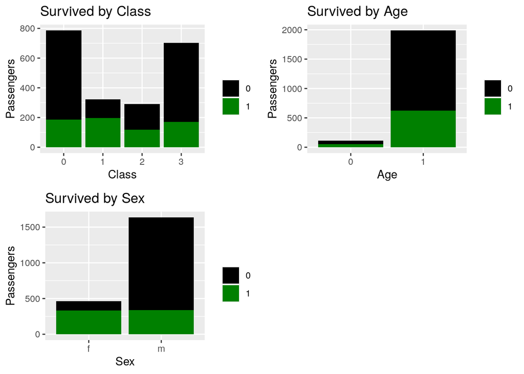

```r
library(grid)
library(ggplot2)
library(gridExtra)
grid.newpage()
plotbyClass<-ggplot(Titanic_S_R,aes(Class,fill=Survived))+geom_bar() +labs(x="Class", y="Passengers")+ guides(fill=guide_legend(title=""))+ scale_fill_manual(values=c("black","#008000"))+ggtitle("Survived by Class")
plotbyAge<-ggplot(Titanic_S_R,aes(Adult,fill=Survived))+geom_bar() +labs(x="Age", y="Passengers")+ guides(fill=guide_legend(title=""))+ scale_fill_manual(values=c("black","#008000"))+ggtitle("Survived by Age")
plotbySex<-ggplot(Titanic_S_R,aes(Sex,fill=Survived))+geom_bar() +labs(x="Sex", y="Passengers")+ guides(fill=guide_legend(title=""))+ scale_fill_manual(values=c("black","#008000"))+ggtitle("Survived by Sex")
grid.arrange(plotbyClass,plotbyAge,plotbySex,ncol=2)
```